# Unsupervised_Learning_Part2

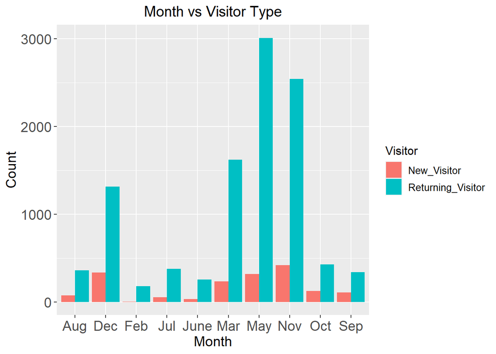

```r
# Relationship between the visitor type and the month

options(repr.plot.width = 15, repr.plot.height = 8)
ggplot(kira, aes(x = Month, fill = Visitor)) +
  geom_bar(position = "dodge") +
  labs(title = "Month vs Visitor Type", x = "Month", y = "Count") +
  theme(axis.text = element_text(size=14),
        axis.title = element_text(size = 14),
        plot.title = element_text(hjust = 0.5, size = 15),
        legend.title = element_text(size=12),
        legend.text = element_text(size=10))
```

```r
# May, November, March and December respectively had the highest numbers of
#Returning visitors
#The Month of February had nearly zero New visitors


# find the means of 'admin_duration', informational_duration', 'productrelated_duration',
#'pagevalues' 'exitrates', and 'bouncerates' per month
month_stats <- kira %>%
  select(Month, Admin, Info_Duration, Prod_Related_Duration, Page_Values, Exit_Rates, Bounce_Rates)%>%
  group_by(Month)%>%
  summarise_all(mean)
month_stats
```

```
## # A tibble: 10 x 7
##    Month Admin Info_Duration Prod_Related_Duration Page_Values Exit_Rates
##    <chr> <dbl>         <dbl>                 <dbl>       <dbl>      <dbl>
##  1 Aug   3.14          35.5                  1273.       5.94      0.0377
##  2 Dec   2.24          39.7                  1148.       6.31      0.0392
##  3 Feb   0.549          2.34                  476.       0.900     0.0728
##  4 Jul   2.42          45.5                  1218.       4.10      0.0453
##  5 June  2.31          19.9                  1197.       3.44      0.0567
##  6 Mar   1.94          31.5                   836.       4.08      0.0408
##  7 May   1.99          27.5                   993.       5.49      0.0472
##  8 Nov   2.64          44.0                  1777.       7.17      0.0370
##  9 Oct   3.72          38.7                  1117.       8.65      0.0290
## 10 Sep   3.33          35.7                  1253.       7.56      0.0303
## # ... with 1 more variable: Bounce_Rates <dbl>
```

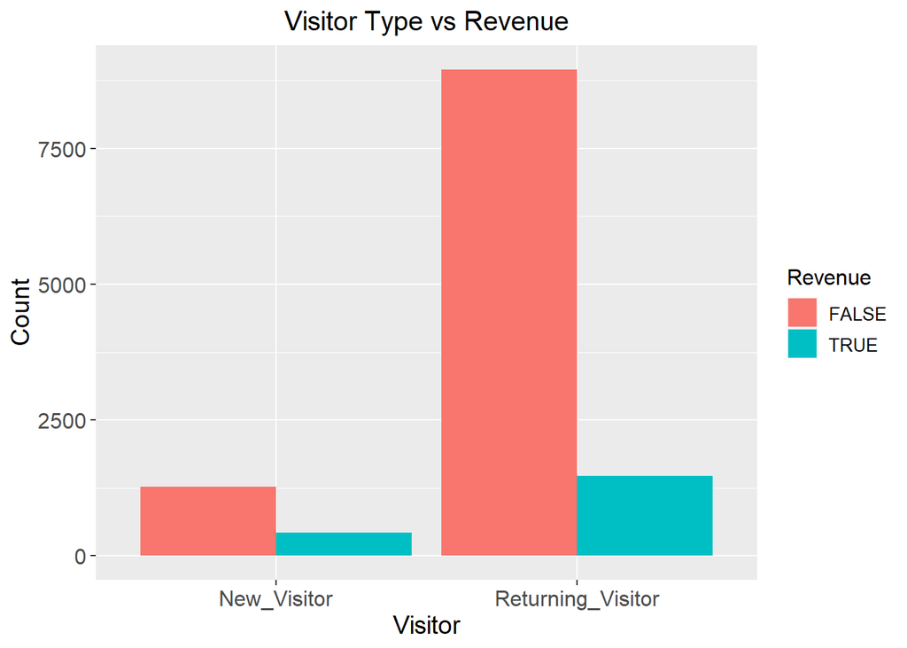

```r
# Relationship between the visitor type and Revenue

options(repr.plot.width = 15, repr.plot.height = 8)
ggplot(kira, aes(x = Visitor, fill = Revenue)) +
  geom_bar(position = "dodge") +
  labs(title = "Visitor Type vs Revenue", x = "Visitor", y = "Count") +
  theme(axis.text = element_text(size=12),
        axis.title = element_text(size = 14),
        plot.title = element_text(hjust = 0.5, size = 15),
        legend.title = element_text(size=12),
        legend.text = element_text(size=10))
```

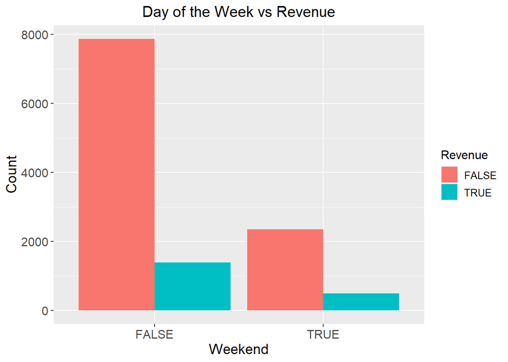

```r
#Returning Visitors had the highest False Revenue


# Relationship between the Weekday and Revenue

options(repr.plot.width = 15, repr.plot.height = 8)
ggplot(kira, aes(x = Weekend, fill = Revenue)) +
  geom_bar(position = "dodge") +
  labs(title = "Day of the Week vs Revenue", x = "Weekend", y = "Count") +
  theme(axis.text = element_text(size=12),
        axis.title = element_text(size = 14),
        plot.title = element_text(hjust = 0.5, size = 15),
        legend.title = element_text(size=12),
        legend.text = element_text(size=10))
```

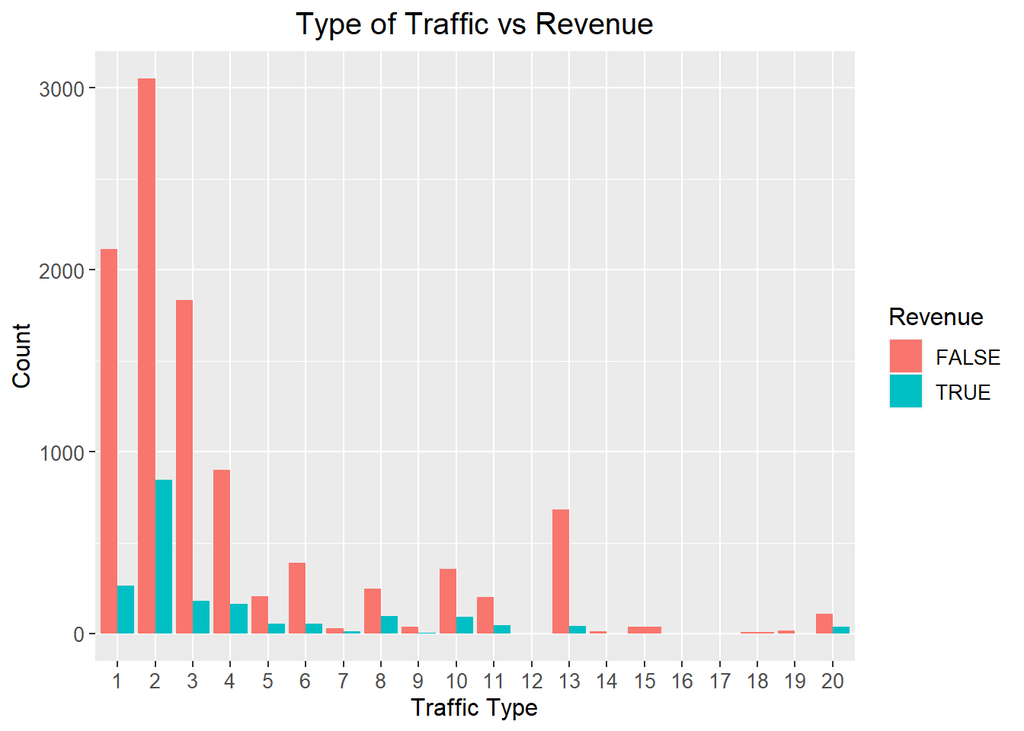

```r
#Most of the Revenue is earned on weekdays and not weekends


# Relationship between the Traffic type and Revenue

options(repr.plot.width = 18, repr.plot.height = 10)
ggplot(kira, aes(x = Traffic, fill = Revenue)) +
  geom_bar(position = "dodge") +
  labs(title = "Type of Traffic vs Revenue", x = "Traffic Type", y = "Count") +
  theme(axis.text = element_text(size=10),
        axis.title = element_text(size = 12),
        plot.title = element_text(hjust = 0.5, size = 15),
        legend.title = element_text(size=12),
        legend.text = element_text(size=10))
```

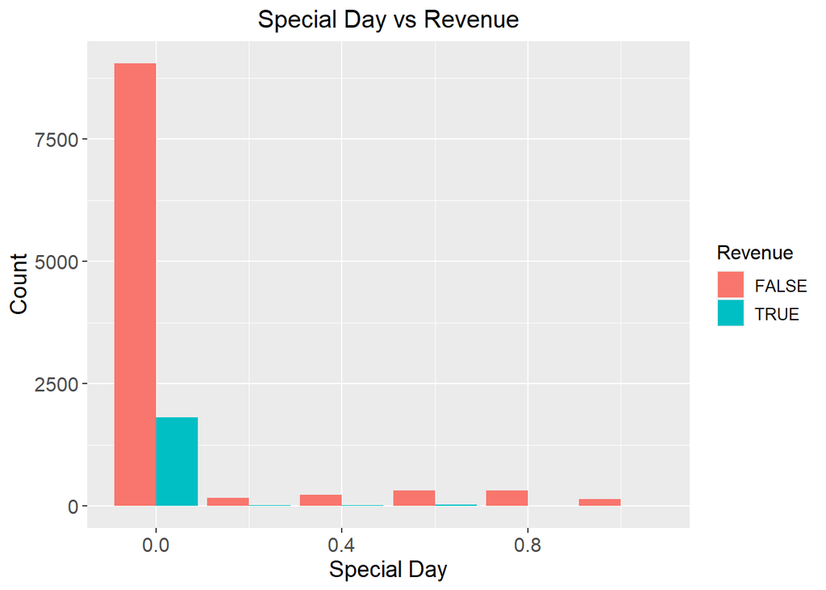

```r
#Traffic 2, 1 and 3 generated the most revenues







# Relationship between the Special Day and Revenue

options(repr.plot.width = 15, repr.plot.height = 8)
ggplot(kira, aes(x = Special_Day, fill = Revenue)) +
  geom_bar(position = "dodge") +
  labs(title = "Special Day vs Revenue", x = "Special Day", y = "Count") +
  theme(axis.text = element_text(size=12),
        axis.title = element_text(size = 14),
        plot.title = element_text(hjust = 0.5, size = 15),
        legend.title = element_text(size=12),
        legend.text = element_text(size=10))
```

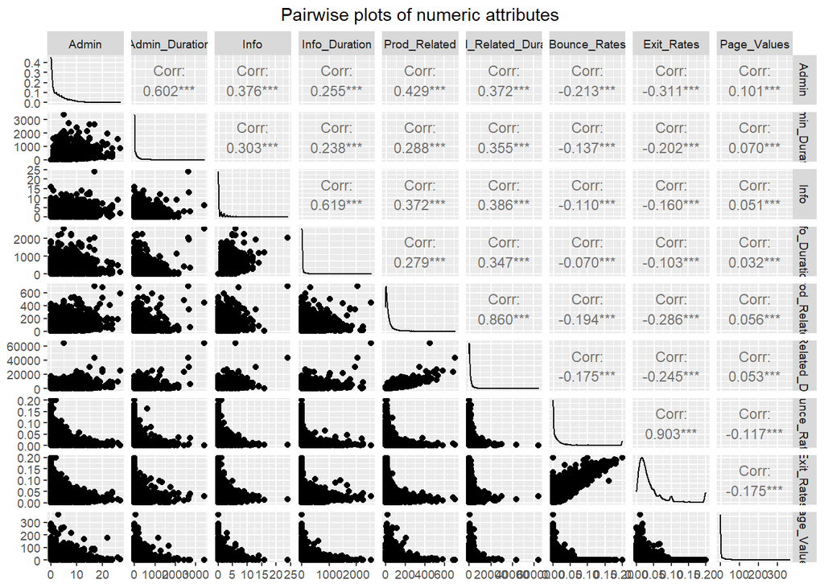

```r
# Plotting pair plots for numeric columns

options(repr.plot.width = 18, repr.plot.height = 18)
ggpairs(numeric, upper = list(continuous = wrap("cor", size = 3))) +
  labs(title = "Pairwise plots of numeric attributes") +
  theme_grey(base_size = 09) +
  theme(plot.title = element_text(hjust = 0.5))
```

There is a very strong positive correlation between:

1. Bounce rates and exit rates
2. Product related site visits and product related duration
3. There is a strong positive correlation between:

Administrative site visits and administrative duration Informational site visits and informational duration

There are weak correlations between the rest of the variables

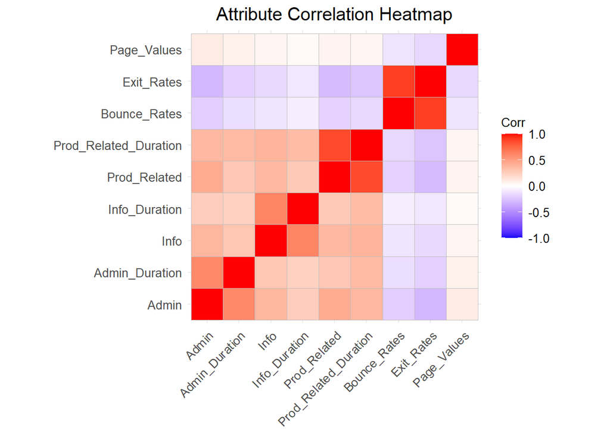

```r
#Correlation Heatmap
options(repr.plot.width = 15, repr.plot.height = 10)
ggcorrplot(cor(numeric), tl.cex = 10) +
  labs(title = "Attribute Correlation Heatmap") +
  theme(axis.title = element_text(size = 14),
        plot.title = element_text(hjust = 0.5, size = 15),
        legend.title = element_text(size=10),
        legend.text = element_text(size=10))
```

*4. Model Development* a) K-Means Clustering

K Means Clustering is an unsupervised learning algorithm that groups similar clusters in a dataset by partitioning the dataset into K distinct,non-overlapping clusters

Implementation

1. Data Preprocessing

```r
#K-Means is an unsupervised machine learning. We, therefore, won't need the label
#column as the algorithm will help us determine what the labels would be

#Separating the dependent variable from the independent
kira_indep <- kira[, 1:17]


#Changing the Factors in the Dataset to integers

#kira_indep[, 12:15] <- lapply(kira_indep[, 12:15], as.integer)
```

2. Categorical Columns Encoding

```r
# one hot encode the categorical variables  to ensure they are
#in a format machine learning can comprehend
dummy <- dummyVars("~ Month + Operating_Systems + Browser + Region + Traffic + Visitor + Weekend", data=kira_indep)
encoded <- data.frame(predict(dummy, newdata = kira_indep))
kira_indep <- cbind(kira_indep[ , 1:10], encoded)
```

3. Normalizing the Data

```r
#We need to scale the data to ensure the distances between data points are
#aligned and in a machine learning comprehensible format.

prep <- preProcess(kira_indep, method=c("range"))
norm.kira <- predict(prep, kira_indep)


#Preview the first few records
head(norm.kira)
```

```
##   Admin Admin_Duration Info Info_Duration Prod_Related Prod_Related_Duration
## 1     0   0.0002941393    0  0.0003920992  0.001418440          1.563122e-05
## 2     0   0.0002941393    0  0.0003920992  0.002836879          1.016029e-03
## 3     0   0.0000000000    0  0.0000000000  0.001418440          0.000000e+00
## 4     0   0.0002941393    0  0.0003920992  0.002836879          5.731448e-05
## 5     0   0.0002941393    0  0.0003920992  0.014184397          9.824223e-03
## 6     0   0.0002941393    0  0.0003920992  0.026950355          2.426226e-03
##   Bounce_Rates Exit_Rates Page_Values Special_Day MonthAug MonthDec MonthFeb
## 1   1.00000000   1.000000           0           0        0        0        1
## 2   0.00000000   0.500000           0           0        0        0        1
## 3   1.00000000   1.000000           0           0        0        0        1
## 4   0.25000000   0.700000           0           0        0        0        1
## 5   0.10000000   0.250000           0           0        0        0        1
## 6   0.07894737   0.122807           0           0        0        0        1
##   MonthJul MonthJune MonthMar MonthMay MonthNov MonthOct MonthSep
```

[output cut: 76 more lines]

4 Determining the optimal number of Clusters

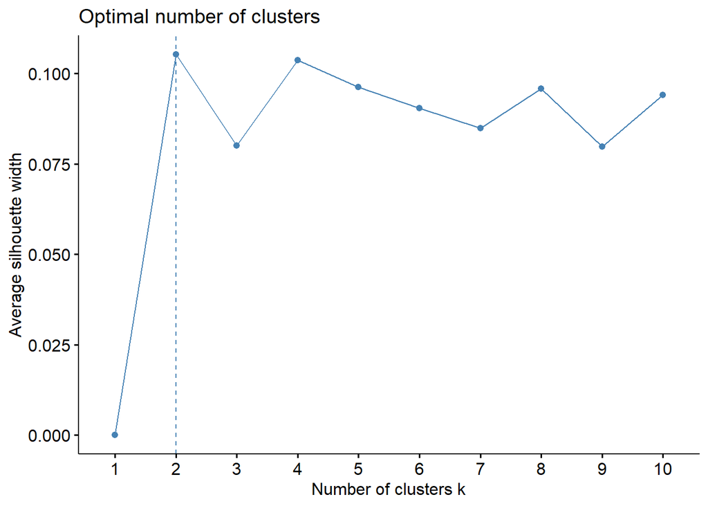

```r
#Using the silhouette method
set.seed(101)
fviz_nbclust(norm.kira, FUN = kmeans, method = "silhouette")
```

```r
#According to the Silhouette method, the optimal clusters is 2.

# Implementing the L-means clustering algorithm with k is 2

means.silo <- kmeans(norm.kira, 2, nstart = 25)

#print(means.silo)

#Checking number of records in each cluster

means.silo$size
```

```
## [1] 9547 2571
```

```r
# viewing the cluster center datapoints by each attribute
means.silo$centers
```

```
##        Admin Admin_Duration       Info Info_Duration Prod_Related
## 1 0.08852888     0.02441004 0.02170403    0.01481089   0.04860983
## 2 0.08068629     0.02413322 0.01975561    0.01151186   0.03467481
##   Prod_Related_Duration Bounce_Rates Exit_Rates Page_Values Special_Day
## 1            0.02026956   0.09676651  0.2021862  0.01642786  0.06496282
## 2            0.01406929   0.12093908  0.2247769  0.01540744  0.05281991
##     MonthAug  MonthDec   MonthFeb   MonthJul  MonthJune  MonthMar  MonthMay
## 1 0.03540379 0.1332356 0.01204567 0.03582277 0.02367236 0.1553368 0.2824971
## 2 0.03695060 0.1462466 0.02605990 0.03500583 0.02255932 0.1439129 0.2454298
##    MonthNov   MonthOct   MonthSep Operating_Systems.1 Operating_Systems.2
## 1 0.2416466 0.04158374 0.03875563          0.02922384         0.681365874
## 2 0.2543757 0.05912096 0.03033839          0.87981330         0.005834306
##   Operating_Systems.3 Operating_Systems.4 Operating_Systems.5
## 1        0.2640620090           0.0207395        0.0006284697
## 2        0.0003889537           0.1089070        0.0000000000
##   Operating_Systems.6 Operating_Systems.7 Operating_Systems.8    Browser.1
## 1         0.001990154         0.000000000         0.001990154 0.0001047449
## 2         0.000000000         0.002722676         0.002333722 0.9408790354
##   Browser.2  Browser.3   Browser.4   Browser.5   Browser.6   Browser.7
## 1  0.822981 0.01099822 0.075835341 0.047973185 0.017806641 0.005132502
## 2  0.000000 0.00000000 0.001166861 0.002333722 0.001555815 0.000000000
##    Browser.8    Browser.9  Browser.10   Browser.11  Browser.12   Browser.13
## 1 0.00000000 0.0001047449 0.016654446 0.0006284697 0.001047449 0.0007332146
## 2 0.05250875 0.0000000000 0.001166861 0.0000000000 0.000000000 0.0003889537
##    Region.1   Region.2  Region.3   Region.4   Region.5   Region.6   Region.7
## 1 0.3797004 0.09489892 0.1922070 0.09343249 0.02922384 0.06735100 0.06881743
## 2 0.4192921 0.08401400 0.2096461 0.10540646 0.01478024 0.06067678 0.03850642
##     Region.8   Region.9 Traffic.1 Traffic.2 Traffic.3  Traffic.4  Traffic.5
## 1 0.03446109 0.03990782 0.2073950 0.3171677 0.1450718 0.08725254 0.02073950
## 2 0.03928433 0.02839362 0.1540257 0.3376118 0.2430961 0.09062622 0.02372618
##    Traffic.6   Traffic.7  Traffic.8   Traffic.9 Traffic.10 Traffic.11
## 1 0.04158374 0.003561328 0.02597675 0.002199644 0.03498481 0.02042526
## 2 0.01750292 0.002333722 0.03656165 0.007779074 0.04395177 0.01983664
##     Traffic.12  Traffic.13  Traffic.14  Traffic.15   Traffic.16   Traffic.17
## 1 0.0001047449 0.075835341 0.001361684 0.001256939 0.0003142348 0.0000000000
## 2 0.0000000000 0.001166861 0.000000000 0.009334889 0.0000000000 0.0003889537
##    Traffic.18  Traffic.19 Traffic.20 VisitorNew_Visitor
## 1 0.001047449 0.001466429 0.01225516          0.1348067
## 2 0.000000000 0.001166861 0.01089070          0.1579152
##   VisitorReturning_Visitor WeekendFALSE WeekendTRUE
## 1                0.8651933    0.7794071   0.2205929
## 2                0.8420848    0.7110074   0.2889926
```

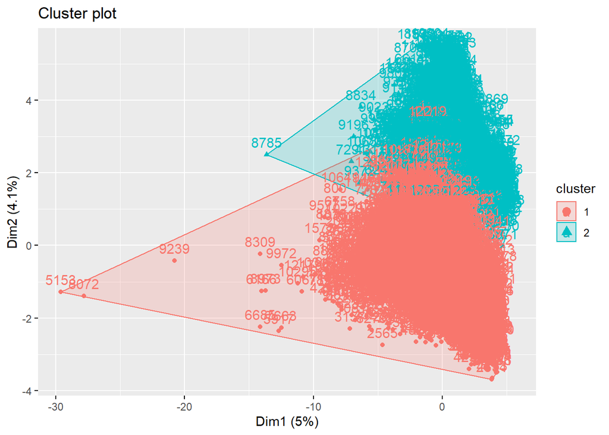

```r
#Visualizing the Clusters

#clusplot(norm.kira, means.silo$cluster, color= T, shade = T, labels =0, lines = 0  )

fviz_cluster(means.silo, data = norm.kira)
```

```r
#Distribution of revenue classes
table(means.silo$cluster, kira$Revenue)
```

```
##
##     FALSE TRUE
##   1  8043 1504
##   2  2183  388
```

```r
#Our Model classifies False revenues correctly with an accuracy of 84.2%
#
```

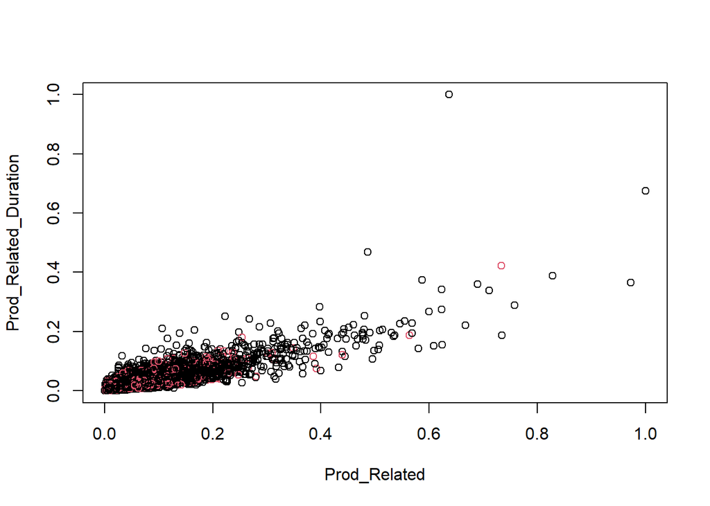

```r
# Comparing variables & the distribution of their data points in the cluster
# Product Related, vs Product Related Duration

plot(norm.kira[, 5:6], col = means.silo$cluster)
```

Would a different method of determining Clusters change the results?